# Chi Square = Z Test

### **NOTES ON STATISTICS, PROBABILITY and MATHEMATICS**

### Chi Square Proportions = Z Test Squared:

This entry corresponds to [this question on CV](http://stats.stackexchange.com/q/173415/67822).

**BACKGROUND:**

The opening of this paper reads:

> Karl Pearson’s famous chi-square contingency test is derived from another statistic, called the z statistic, based on the Normal distribution. The simplest versions of $\chi^2$ can be shown to be mathematically identical to equivalent z tests. The tests produce the same result in all circumstances. For all intents and purposes “chi-squared” could be called “z-squared”. The critical values of $\chi^2$ for one degree of freedom are the square of the corresponding critical values of z.

This has been asserted multiple times in CV ([here](http://stats.stackexchange.com/a/2443/67822), [here](http://stats.stackexchange.com/a/108566/67822), [here](http://stats.stackexchange.com/a/158480/67822) and others).

And indeed we can [prove](http://math.stackexchange.com/q/1384338/152225) that $\chi^2_{1\,df}$ is equivalent to $X^2$ with $X\sim N(0,1)$:

Let’s say that $X \sim N(0,1)$ and that $Y=X^2$ and find the density of $Y$ by using the $\text{cdf}$ method:

$$p(Y \leq y) = p(X^2 \leq y)= p(-\sqrt{y}
\leq x \leq \sqrt{y}).$$
The problem is that we cannot integrate in close form the density of the normal distribution. But we can express it:

$$F_X(y) = F_X(\sqrt{y})-
F_X(-\sqrt[]{y}).$$
Taking the derivative:

$$f_X(y)=
F_X'(\sqrt{y})\,\frac{1}{2\sqrt{y}}+
F_X'(\sqrt{-y})\,\frac{1}{2\sqrt{y}}.$$

Since the values of the normal $\text{pdf}$ are symmetrical:

$f_X(y)= F_X'(\sqrt{y})\,\frac{1}{\sqrt{y}}$. Equating this to the $\text{pdf}$ of the normal (now the $x$ in the $\text{pdf}$ will be $\sqrt{y}$ to be plugged into the $e^{-\frac{x^2}{2}}$ part of the normal $\text{pdf}$); and remembering to in include $\frac{1}{\sqrt{y}}$ at the end:

$$f_X(y)=
F_X'(\sqrt[]{y})\,\frac{1}{\sqrt[]{y}}=
\frac{1}{\sqrt{2\pi}}\,e^{-\frac{y}{2}}\,
\frac{1}{\sqrt[]{y}}=\frac{1}{\sqrt{2\pi}}\,e^{-\frac{y}{2}}\,
y^{\frac{1}{2}- 1}$$

Compare to the pdf of the chi square:

$$f_X(x)=
\frac{1}{2^{\nu/2}\Gamma(\frac{\nu}{2})}e^{\frac{-x}{2}}x^{\frac{\nu}{2}-1}$$

Since $\Gamma(1/2)=\sqrt{\pi}$, for $1$ df, we have derived exactly the $\text{pdf}$ of the chi square.

Further, if we call the function `prop.test()` in R we are invoking the same $\chi^2$ test as if we decide upon `chisq.test()`.

**THE QUESTION:**

So I get all these points, yet I still don’t know how they apply to the actual implementation of these two tests for two reasons:

1. *A z-test is not squared.*
2. *The actual test statistics are completely different:*

The value of the [test-statistic for a $\chi^2$](https://en.wikipedia.org/wiki/Pearson%27s_chi-squared_test) is:

$$\chi^2 = \displaystyle \sum_{i=1}^{n}
\frac{(O_i - E_i)^2}{E_i} = \,N\, \displaystyle \sum_{i=1}^n \,p_i\,
\left(\frac{\frac{O_i}{N} - p_i}{p_i}\right)^2=
\frac{n(n_{11}\,n_{22}\,-\,n_{12}\,n_{21})^2}{n_{+1}\,n_{+2}\,n_{1+}\,n_{2+}}$$
where

$\chi^2$ = Pearson’s cumulative test statistic, which asymptotically approaches a $\chi^2$ distribution. $O_i$ = the number of observations of type $i$; $N$ = total number of observations; $E_i$ = $N p_i$ = the expected (theoretical) frequency of type $i$, asserted by the null hypothesis that the fraction of type $i$ in the population is $p_i$; $n$ = the number of cells in the table.

Of note the last expression of the $\chi^2$ statistic applies to $2$x$2$ tables and the nomenclature is as follows:

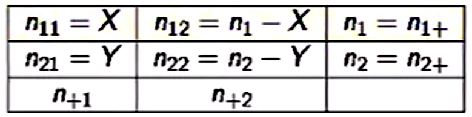

On the other hand, the test statistic for a $z$-test is:

$\large \displaystyle Z = \frac{\frac{x_1}{n_1}-\frac{x_2}{n_2}}{\sqrt{p\,(1-p)(1/n_1+1/n_2)}}$ with $\displaystyle p = \frac{x_1\,+\,x_2}{n_1\,+\,n_2}$, where $x_1$ and $x_2$ are the number of “successes”, over the number of subjects in each one of the levels of the categorical variables, i.e. $n_1$ and $n_2$.

This formula seems to rely on the binomial distribution.

These two tests statistics are clearly different, and [result in different results for the actual test statistics, as well as for the *p*-values](http://stats.stackexchange.com/a/167988/67822): `5.8481` for the $\chi^2$ and `2.4183` for the z-test. The *p*-value for the $\chi^2$ test is `0.01559`, while for the z-test is `0.0077`. The difference explained by two-tailed versus one-tailed: $\small 0.01559/2=0.007795$.

In the example on the last hyperlink the $\chi^2$ is almost the square of the z-test statistic, but not quite, and the p-values are different.

**ANSWER:**

Performing the `chisq.test()` with `correct=FALSE` yields exactly the square of the z-test: in the output numbers included in the end of the question $\small 2.4183^2=5.84817$.

These are two identical tests. $Z$ squared is the chi-square statistic. Let you have $2x2$ frequency table where columns are the two groups and the rows are “success” and “failure”. Then the so called expected frequencies of the chi-square test in a given column is the weighted (by the groups’ $N$) average column (group) profile multiplied by that group’s $N$. Thus, it comes that chi-square tests the deviation of each of the two groups profiles from this average group profile - which is equivalent to testing the groups’ profiles difference from each other, the $z$-test of proportions.

Let us have a $2x2$ frequency table where columns are two groups of respondents and rows are the two responses “Yes” and “No”. And we’ve turned the frequencies into the **proportions** within group, i.e. into the vertical *profiles*:

```
      Gr1   Gr2  Total
Yes   p1    p2     p
No    q1    q2     q
      --------------
     100%  100%   100%
      n1    n2     N
```

The usual (not Yates corrected) $\chi^2$ of this table, after you substitute proportions instead of frequencies in its formula, looks like this:

$$n_1\left[\frac{(p_1-p)^2}{p}+\frac{(q_1-q)^2}{q}\right]+n_2\left[\frac{(p_2-p)^2}{p}+\frac{(q_2-q)^2}{q}\right]=
\frac{n_1(p_1-p)^2+n_2(p_2-p)^2}{pq} \tag {*}$$

Remember that $p= \frac{n_1p_1+n_2p_2}{n_1+n_2}$, the element of the weighted average profile of the two profiles `(p1,q1)` and `(p2,q2)`, and plug it in the formula, to obtain

$$...=
\frac{(p_1-p_2)^2(n_1^2n_2+n_1n_2^2)}{pqN^2}$$

Divide both numerator and denominator by the $(n_1^2n_2+n_1n_2^2)$ and get
$$\frac{(p_1-p_2)^2}{pq(1/n_1+1/n_2)}=Z^2,$$

the squared z-statistic of the z-test of proportions for “Yes” response.

Thus, the $2x2$ homogeneity Chi-square statistic (and test) is equivalent to the z-test of two proportions. The so called expected frequencies computed in the chi-square test in a given column is the weighted (by the group `n`) average vertical profile (i.e. the profile of the “average group”) multiplied by that group’s `n`. Thus, it comes out that chi-square tests the deviation of each of the two groups profiles from this average group profile, - which is equivalent to testing the groups’ profiles difference from each other, which is the z-test of proportions.

This is one demonstration of a link between a variables association measure (chi-square) and a group difference measure (z-test statistic). Attribute associations and group differences are (often) the two facets of the same thing.

Showing the expansion in the first line above $(*)$:

$$\begin{align}
\small
n_1\left[\frac{(p_1-p)^2}{p}+\frac{(q_1-q)^2}{q}\right]+n_2\left[\frac{(p_2-p)^2}{p}+\frac{(q_2-q)^2}{q}\right]
&=
\frac{n_1(p_1-p)^2q}{pq}+\frac{n_1(q_1-q)^2p}{pq}+\frac{n_2(p_2-p)^2q}{pq}+\frac{n_2(q_2-q)^2p}{pq}\\[2ex]
&=
\frac{n_1(p_1-p)^2(1-p)+n_1(1-p_1-1+p)^2p+n_2(p_2-p)^2(1-p)+n_2(1-p_2-1+p)^2p}{pq}\\[2ex]
&=
\frac{n_1(p_1-p)^2(1-p)+n_1(p-p_1)^2p+n_2(p_2-p)^2(1-p)+n_2(p-p_2)^2p}{pq}\\[2ex]
&= \frac{[n_1(p_1-p)^2][(1-p)+p]+[n_2(p_2-p)^2][(1-p)+p]}{pq} =
\frac{n_1(p_1-p)^2+n_2(p_2-p)^2}{pq}.
\end{align}$$

[Home Page](http://rinterested.github.io/statistics/index.html)

**NOTE: These are tentative notes on different topics for personal use - expect mistakes and misunderstandings.**